# Stat 579 - Homework #7

10/17/2019

## Human Development Index

The United Nations Development Programme publishes an annual report on human development across the globe. An interactive tool to visualize some of the data is available at http://hdr.undp.org/en/data

1. Download the RMarkdown file with these homework instructions to use as a template for your work. Make sure to replace “Your Name” in the YAML with your name.
2. Download the data for 2018 from the left side tab stating [Download 2018 Human Development Data Bank](http://hdr.undp.org/sites/default/files/2018_all_indicators.xlsx). This will lead you to an Excel document. Open it and comment on the structure you find in the `Data’ sheet. Comment on the overall structure in the context of “long” versus “wide” data.

### This is a really big dataset. There are almost 26000 rows that detail 14 dimensions with 40+ indicators and up to 28 years of data. This is, by nature, untidy because there are separate variables for each year – meaning that it is in wide format. In a long structure, there would be a separate row for each year.

3. There is an R package available online (on CRAN) that allows to read Excel files. Find the package, (install it if necessary), load it and read the `Data’ sheet “2018_all_indicators.xlsx” into R (make use of the available parameters). Compare the result in R with what is visible in Excel. Keep track of and comment on all steps in the process.

### Package name – ‘openxlsx’, install via CRAN. The two dataframes look pretty similar.

```r
library(openxlsx)
hdi <- read.xlsx("2018_all_indicators.xlsx", sheet = 1, startRow = 1, colNames = TRUE)
head(hdi)
```

```
##           dimension indicator_id indicator_name iso3        country_name
## 1 Composite indices       146206       HDI rank  AFG         Afghanistan
## 2 Composite indices       146206       HDI rank  ALB             Albania
## 3 Composite indices       146206       HDI rank  DZA             Algeria
## 4 Composite indices       146206       HDI rank  AND             Andorra
## 5 Composite indices       146206       HDI rank  AGO              Angola
## 6 Composite indices       146206       HDI rank  ATG Antigua and Barbuda
##   1990 1991 1992 1993 1994 1995 1996 1997 1998 1999 2000 2001 2002 2003
## 1   NA   NA   NA   NA   NA   NA   NA   NA   NA   NA   NA   NA   NA   NA
## 2   NA   NA   NA   NA   NA   NA   NA   NA   NA   NA   NA   NA   NA   NA
## 3   NA   NA   NA   NA   NA   NA   NA   NA   NA   NA   NA   NA   NA   NA
## 4   NA   NA   NA   NA   NA   NA   NA   NA   NA   NA   NA   NA   NA   NA
## 5   NA   NA   NA   NA   NA   NA   NA   NA   NA   NA   NA   NA   NA   NA
## 6   NA   NA   NA   NA   NA   NA   NA   NA   NA   NA   NA   NA   NA   NA
##   2004 2005 2006 2007 2008 2009 2010 2011 2012 2013 2014 2015 2016 2017
## 1   NA   NA   NA   NA   NA   NA   NA   NA   NA   NA   NA   NA  168  168
## 2   NA   NA   NA   NA   NA   NA   NA   NA   NA   NA   NA   NA   69   68
## 3   NA   NA   NA   NA   NA   NA   NA   NA   NA   NA   NA   NA   83   85
## 4   NA   NA   NA   NA   NA   NA   NA   NA   NA   NA   NA   NA   35   35
## 5   NA   NA   NA   NA   NA   NA   NA   NA   NA   NA   NA   NA  145  147
## 6   NA   NA   NA   NA   NA   NA   NA   NA   NA   NA   NA   NA   70   70
##   9999
## 1   NA
## 2   NA
## 3   NA
## 4   NA
## 5   NA
## 6   NA
```

```r
str(hdi)
```

```
## 'data.frame':    25636 obs. of  34 variables:
##  $ dimension     : chr  "Composite indices" "Composite indices" "Composite indices" "Composite indices" ...
##  $ indicator_id  : num  146206 146206 146206 146206 146206 ...
##  $ indicator_name: chr  "HDI rank" "HDI rank" "HDI rank" "HDI rank" ...
##  $ iso3          : chr  "AFG" "ALB" "DZA" "AND" ...
##  $ country_name  : chr  "Afghanistan" "Albania" "Algeria" "Andorra" ...
##  $ 1990          : num  NA NA NA NA NA NA NA NA NA NA ...
##  $ 1991          : num  NA NA NA NA NA NA NA NA NA NA ...
##  $ 1992          : num  NA NA NA NA NA NA NA NA NA NA ...
##  $ 1993          : num  NA NA NA NA NA NA NA NA NA NA ...
##  $ 1994          : num  NA NA NA NA NA NA NA NA NA NA ...
##  $ 1995          : num  NA NA NA NA NA NA NA NA NA NA ...
##  $ 1996          : num  NA NA NA NA NA NA NA NA NA NA ...
##  $ 1997          : num  NA NA NA NA NA NA NA NA NA NA ...
##  $ 1998          : num  NA NA NA NA NA NA NA NA NA NA ...
```

[output cut: 20 more lines]

For the write-up assume, that the Excel file is in the same folder as the homework Rmd file. Also assume, that both the TA and I have updated versions of all packages you use, i.e. only load packages but do not install any in the code. 4. Bring the data into a long form. What setting do you use for missing values? How many indicators are in the data? Use `ggplot2` to show a barchart.

```r
library(tidyverse)

hdi_long <- hdi %>%
  gather(key=Year,value=HDI, c('1990':'2017')) %>%
  filter(!is.na(HDI))

tail(hdi_long)
```

```
##                                 dimension indicator_id
## 326353 Work, employment and vulnerability       147906
## 326354 Work, employment and vulnerability       147906
## 326355 Work, employment and vulnerability       147906
## 326356 Work, employment and vulnerability       147906
## 326357 Work, employment and vulnerability       147906
## 326358 Work, employment and vulnerability       147906
##                                          indicator_name iso3 country_name
## 326353 Youth not in school or employment (% ages 15-24)  GUY       Guyana
## 326354 Youth not in school or employment (% ages 15-24)  IDN    Indonesia
## 326355 Youth not in school or employment (% ages 15-24)  MEX       Mexico
## 326356 Youth not in school or employment (% ages 15-24)  NZL  New Zealand
## 326357 Youth not in school or employment (% ages 15-24)  SRB       Serbia
## 326358 Youth not in school or employment (% ages 15-24)  ZAF South Africa
##        9999 Year  HDI
## 326353 35.2 2017 35.2
## 326354 21.4 2017 21.4
## 326355 18.7 2017 18.7
## 326356 11.8 2017 11.8
## 326357 17.6 2017 17.6
## 326358 31.1 2017 31.1
```

```r
hdi_long %>%
  group_by(indicator_name) %>%
  summarise(n=n())
```

```
## # A tibble: 136 x 2
##    indicator_name                                                         n
##    <chr>                                                              <int>
##  1 Adjusted net savings (% of GNI)                                     1472
##  2 Adolescent birth rate (births per 1,000 women ages 15-19)           2220
##  3 Antenatal care coverage, at least one visit (%)                      493
##  4 Carbon dioxide emissions (kg per 2011 PPP $ of GDP)                 2350
##  5 Carbon dioxide emissions, per capita (tonnes)                       1689
##  6 Coefficient of human inequality                                     1153
##  7 Concentration index (exports) (value)                               2660
##  8 Contraceptive prevalence, any method (% of married or in-union wo…   543
##  9 Current health expenditure (% of GDP)                               2976
## 10 Domestic credit provided by financial sector (% of GDP)             2613
## # … with 126 more rows
```

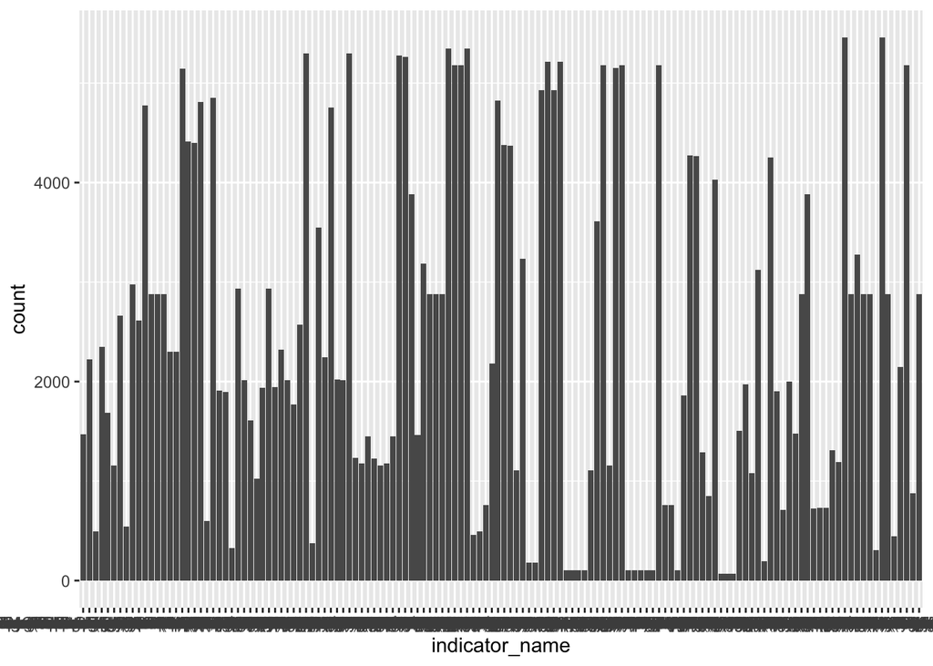

```r
### There are 136 different indicators.

hdi_long %>%
  ggplot(aes(x=indicator_name)) +
  geom_bar()
```

5. Two of the indicators are called `Human Development Index (HDI), male` and `Human Development Index (HDI), female`. Comment on this from a tidy data perspective.

### This data is not ‘tidy’ because a single column has information on multiple variables (HDI and gender). To truly tidy up this data, we should move Gender into its own column.

6. Use `tidyr` and `dplyr` functionality to get the data set into a format to be able to recreate the plot below (from the United Nations website) in ggplot. Use a classification of HDI of very high for [0.8,1], high for [0.7, .8), medium for [.55, .7) and low below .55), color lines by the last available year. 1pt of extra for using a better color scheme than is shown below.

```r
hdi_long <- hdi_long %>%
  filter(indicator_name == 'Human Development Index (HDI)') %>%
  filter(!is.na(HDI)) %>%
  mutate(threshold= ifelse(`9999` >= 0.8, "Very High", ifelse(`9999`>=0.7, "High", ifelse(`9999`>=0.55, "Medium", "Low"))))

head(hdi_long)
```

```
##           dimension indicator_id                indicator_name iso3
## 1 Composite indices       137506 Human Development Index (HDI)  ALB
## 2 Composite indices       137506 Human Development Index (HDI)  DZA
## 3 Composite indices       137506 Human Development Index (HDI)  ARG
## 4 Composite indices       137506 Human Development Index (HDI)  ARM
## 5 Composite indices       137506 Human Development Index (HDI)  AUS
## 6 Composite indices       137506 Human Development Index (HDI)  AUT
##   country_name  9999 Year   HDI threshold
## 1      Albania 0.785 1990 0.645      High
## 2      Algeria 0.754 1990 0.577      High
## 3    Argentina 0.825 1990 0.704 Very High
## 4      Armenia 0.755 1990 0.631      High
## 5    Australia 0.939 1990 0.866 Very High
## 6      Austria 0.908 1990 0.795 Very High
```

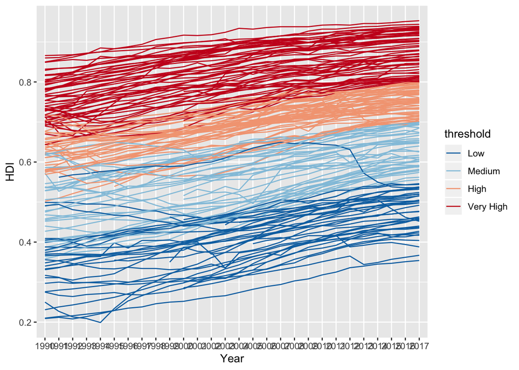

```r
keeps <- c("country_name","Year", "HDI", "threshold", "9999")
hdi_long2 <- hdi_long[keeps]

hdi_long2$threshold <- factor(hdi_long2$threshold, levels=c("Low", "Medium", "High", "Very High"))


library(RColorBrewer)

hdi_long2 %>%
  ggplot(aes(x=Year, y=HDI, group=country_name)) +
  geom_line(aes(color=threshold)) +
  scale_colour_brewer(palette = "RdBu", direction = -1) #+
```

```r
  #theme_dark()

head(hdi_long2, 20)
```

```
##                        country_name Year   HDI threshold  9999
## 1                           Albania 1990 0.645      High 0.785
## 2                           Algeria 1990 0.577      High 0.754
## 3                         Argentina 1990 0.704 Very High 0.825
## 4                           Armenia 1990 0.631      High 0.755
## 5                         Australia 1990 0.866 Very High 0.939
## 6                           Austria 1990 0.795 Very High 0.908
## 7                           Bahrain 1990 0.746 Very High 0.846
## 8                        Bangladesh 1990 0.387    Medium 0.608
## 9                          Barbados 1990 0.716 Very High 0.800
## 10                          Belgium 1990 0.806 Very High 0.916
## 11                           Belize 1990 0.644      High 0.708
## 12                            Benin 1990 0.348       Low 0.515
## 13 Bolivia (Plurinational State of) 1990 0.536    Medium 0.693
## 14                         Botswana 1990 0.581      High 0.717
## 15                           Brazil 1990 0.611      High 0.759
## 16                Brunei Darussalam 1990 0.782 Very High 0.853
## 17                         Bulgaria 1990 0.694 Very High 0.813
## 18                          Burundi 1990 0.297       Low 0.417
## 19                         Cambodia 1990 0.364    Medium 0.582
## 20                         Cameroon 1990 0.440    Medium 0.556
```

```r
### I chose this color scheme over gradient/sequential schemes because I thought that it was important to be able to see the outliers, or countries that suddenly jumped/fell in HDI over the years. With color schemes that are closer together, it is harder to capture those movements.
```

Due date: please refer to the website and Canvas for the due date.

For the submission: submit your solution in an R Markdown file and (just for insurance) submit the corresponding html/word file with it.